# Cyclistic

Agbebiyi A

3/14/2022

## Cyclistic Bikes Usage by Member Type

> Cyclistic has two categories of membership: Members and Casual. The primary difference these two categories lies in the type of pricing plan purchased. Members outrightly purchased annual plans while casual members purchased either the single-ride passes or full-day passes. The finance team at Cyclistic has concluded that annual members are much more profitable that casual members. Cyclistic hopes to be able convert its casual members to annual members via a marketing campaign.

> Three questions will guide the future marketing program:
1. How do annual members and casual riders use Cyclistic bikes differently?
2. Why would casual riders buy Cyclistic annual membership?
3. How can Cyclistic use digital media to influence casual riders to become members?

### **Objective**

The objective of this project is to answer the first question:

> *How do annual members and causal members use Cyclistic bikes differently?*

## **Executive Summary**

> Annual members had an overwhelming preference for Classic bikes with usage of **46.5%** and casual members, **29.0%**. With Electric bikes, **13.5%** of annual members preferred them to **11.0%** of casual members.

# **Method**

The data is located here: [Cyclistic Data](https://divvy-tripdata.s3.amazonaws.com/index.html) on Amazon Web Services cloud platform.

The data is stored in an index of bucket “divvy-tripdata” which is an index of monthly comma separated values (csv) files. The data has been made available by Motivate International Inc. under this [license](https://ride.divvybikes.com/data-license-agreement). The last 12 months of data was used: **February 2021 to January 2022**. The files were each inspected to check for consistency of data type and columns before they were loaded in RStudio.

Import and create dataframe:

```r
cyclistic <- list.files(path ="Cyclistic_CVS_/", pattern =".csv"
                            ,full.names = T)

cyclistic_df <- map_dfr(.x = cyclistic, .f = read_csv,
                            show_col_types =FALSE)
```

A quick inspection of the dataframe created:

```r
summary(cyclistic_df)
```

```
##    ride_id          rideable_type       started_at          ended_at
##  Length:4937939     Length:4937939     Length:4937939     Length:4937939
##  Class :character   Class :character   Class :character   Class :character
##  Mode  :character   Mode  :character   Mode  :character   Mode  :character
##
##
##
##
##  start_station_name start_station_id   end_station_name   end_station_id
##  Length:4937939     Length:4937939     Length:4937939     Length:4937939
##  Class :character   Class :character   Class :character   Class :character
##  Mode  :character   Mode  :character   Mode  :character   Mode  :character
##
##
##
##
##    start_lat       start_lng         end_lat         end_lng
##  Min.   :41.64   Min.   :-87.84   Min.   :41.39   Min.   :-88.97
##  1st Qu.:41.88   1st Qu.:-87.66   1st Qu.:41.88   1st Qu.:-87.66
##  Median :41.90   Median :-87.64   Median :41.90   Median :-87.64
##  Mean   :41.90   Mean   :-87.65   Mean   :41.90   Mean   :-87.65
##  3rd Qu.:41.93   3rd Qu.:-87.63   3rd Qu.:41.93   3rd Qu.:-87.63
##  Max.   :45.64   Max.   :-73.80   Max.   :42.17   Max.   :-87.49
##                                   NA's   :4063    NA's   :4063
##  member_casual
##  Length:4937939
##  Class :character
##  Mode  :character
##
##
##
##
```

A look at the feedback above reveals there are NA as well as missing values in some of the columns. These columns do not ordinarily impact on the outcome of the business task but for the sake of completeness, they will be removed:

```r
cyclistic_df_na <- cyclistic_df %>% na.omit()
```

It is assumed that each ride is unique as such each ride_id should be unique and unrepeatable. For this reason, the ride_id column is filtered for unique values:

```r
cyclistic_drm<-cyclistic_df_na %>%
     distinct(ride_id, .keep_all = TRUE)
```

The **member_casual** column name could do with a better title: **member_type** and in the same vein, the **member** value in that column will be replaced with **annual** for a clearer distinction of member types.

```r
cyclistic_drm$member_casual[cyclistic_drm$member_casual == "member"] <- "annual"

cyclistic_cln<- cyclistic_drm %>% rename("member_type" = "member_casual")
```

From the summary results above, it can be seen that started_at and ended_at columns are stored as characters, they need to be converted the appropriate format, this will make it possible to find the difference between the start and end time for each trip and create a column for the results in **ride_length**:

```r
cyclistic_cln$started_at<- mdy_hms(cyclistic_cln$started_at)

cyclistic_cln$ended_at<- mdy_hms(cyclistic_cln$ended_at)

cyclistic_m<- cyclistic_cln %>%
  mutate(ride_length = hms::as_hms(ended_at - started_at))
```

Similarly, a new column containing the day of the week, **day_of_week**, in numerical form will be created to ascertain the days that riders used the bikes; 1 representing Sunday, 2 representing Monday and so on.

```r
cyclistic_m<- cyclistic_m %>% mutate(day_of_week = wday(started_at))
```

Calling View on cyclistic_m and foll0wing a quick inspection of the **ride_length** column revealed that some *unique* ride_ids have the same start and end times which does not provide meaningfully contribution since they are essentially null values, negative values will also be removed; they will be removed by subsetting:

```r
null_rides<-cyclistic_m %>%
 subset(cyclistic_m$ride_length == 00:00:00)

neg_rides <- cyclistic_m %>%
  subset(cyclistic_m$ride_length < 00:00:00)
```

A docked bike is not a type of bike but rather a process or system is storing bikes in specified places after use. The rideable_type column has entries with “Docked bikes”:

```r
cyclistic_sdb <- cyclistic_m %>%
  subset(cyclistic_m$rideable_type != 'docked_bike')
```

All other observations are contained below:

```r
cyclistic_sset <- cyclistic_m %>%
  subset(cyclistic_m$ride_length > 00:00:00 & cyclistic_m$rideable_type != 'docked_bike')
```

A minimalist selection of key columns:

```r
cyclistic_mn <- cyclistic_sset %>%
  select(ride_id, rideable_type,member_type,ride_length,day_of_week)

cyclistic_mn
```

```
## # A tibble: 3,734,665 x 5
##    ride_id          rideable_type member_type ride_length day_of_week
##    <chr>            <chr>         <chr>       <time>            <dbl>
##  1 89E7AA6C29227EFF classic_bike  annual      07'00"                6
##  2 0FEFDE2603568365 classic_bike  casual      20'00"                1
##  3 E6159D746B2DBB91 electric_bike annual      09'00"                3
##  4 B32D3199F1C2E75B classic_bike  annual      05'00"                3
##  5 83E463F23575F4BF electric_bike annual      15'00"                3
##  6 BDAA7E3494E8D545 electric_bike casual      06'00"                4
##  7 A772742351171257 classic_bike  casual      01'00"                2
##  8 295476889D9B79F8 classic_bike  annual      02'00"                5
##  9 362087194BA4CC9A classic_bike  annual      23'00"                7
## 10 21630F715038CCB0 classic_bike  annual      18'00"                7
## # ... with 3,734,655 more rows
```

## Summary Statistics

Here is summary of some measurable statistics:

```
## .
##
##  3  Variables      3734665  Observations
## --------------------------------------------------------------------------------
## rideable_type
##        n  missing distinct
##  3734665        0        2
##
## Value       classic_bike electric_bike
## Frequency        2816475        918190
## Proportion         0.754         0.246
## --------------------------------------------------------------------------------
## member_type
##        n  missing distinct
##  3734665        0        2
##
## Value       annual  casual
## Frequency  2243330 1491335
## Proportion   0.601   0.399
## --------------------------------------------------------------------------------
## ride_length [secs]
##        n  missing distinct
##  3734665        0     1274
##
## lowest : 00:01:00 00:02:00 00:03:00 00:04:00 00:05:00
## highest: 24:54:00 24:56:00 24:57:00 24:58:00 25:00:00
## --------------------------------------------------------------------------------
```

## Visualisation

A visualisation of rides by day of week by members:

```
## # A tibble: 14 x 4
##    day_of_week member_type      n percentage
##          <dbl> <chr>        <int> <chr>
##  1           1 annual      273052 7.3%
##  2           1 casual      286386 7.7%
##  3           2 annual      310625 8.3%
##  4           2 casual      169686 4.5%
##  5           3 annual      339635 9.1%
##  6           3 casual      154751 4.1%
##  7           4 annual      345199 9.2%
##  8           4 casual      158767 4.3%
##  9           5 annual      333549 8.9%
## 10           5 casual      169493 4.5%
## 11           6 annual      324667 8.7%
## 12           6 casual      213206 5.7%
## 13           7 annual      316603 8.5%
## 14           7 casual      339046 9.1%
```

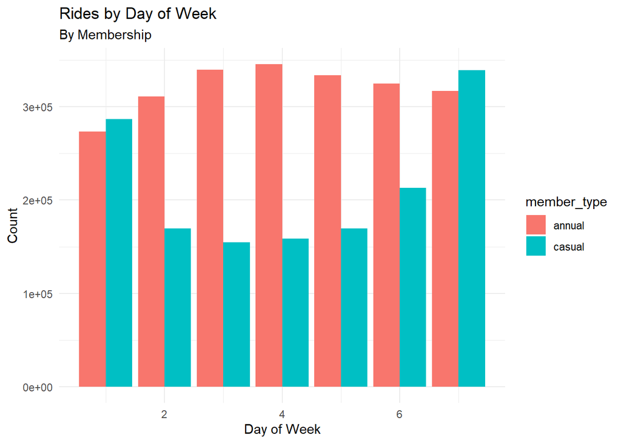

```r
cwdm
```

About a third (32.6%) of all rides occurred over the weekends (Saturday and Sunday) with Saturday representing about a fifth (17.6%) of rides. The remaining rides occurred weekdays (Monday to Friday)

From the graph above, it can clearly be seen that **casual** members were not as inclined to weekday rides as were **annual** members. Casual members rode more over the weekends than weekdays. Saturday was the most active day for casual riders.

A visualisation of rides by ride duration:

```
## # A tibble: 1,984 x 4
##    ride_length member_type      n percentage
##    <time>      <chr>        <int>      <dbl>
##  1 01'00"      annual       28128      0.753
##  2 01'00"      casual       12779      0.342
##  3 02'00"      annual       63753      1.71
##  4 02'00"      casual       13938      0.373
##  5 03'00"      annual      116429      3.12
##  6 03'00"      casual       25616      0.686
##  7 04'00"      annual      152018      4.07
##  8 04'00"      casual       40849      1.09
##  9 05'00"      annual      162964      4.36
## 10 05'00"      casual       53661      1.44
## # ... with 1,974 more rows
```

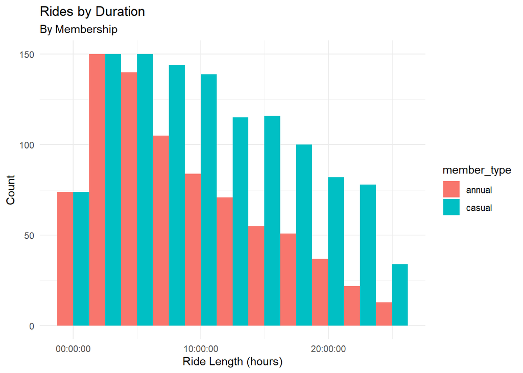

```r
crl
```

A visualisation of rides by bike type:

```
## # A tibble: 4 x 4
##   rideable_type member_type       n percentage
##   <chr>         <chr>         <int> <chr>
## 1 classic_bike  annual      1737339 46.5%
## 2 classic_bike  casual      1079136 28.9%
## 3 electric_bike annual       505991 13.5%
## 4 electric_bike casual       412199 11.0%
```

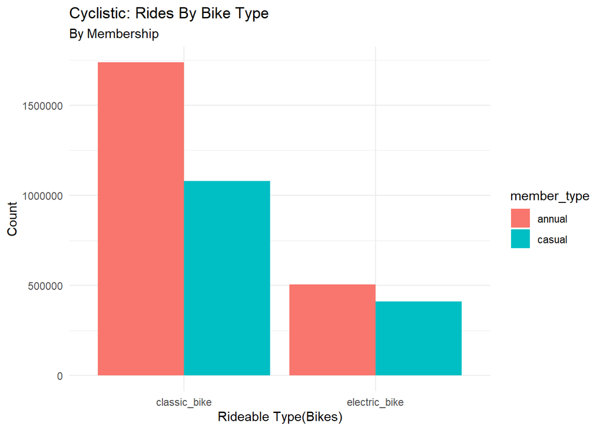

```r
crt
```

Of the two types of bikes available, the Classic bike was the preferred bike with about 75.4% of rides. By member type, 46.5% of annual members preferred them compared to 28.9% of casual members. The Electric bike was preferred by 24.5% of riders with 13.5% being annual members and 11% being casual riders. Annual members showed an overwhelming preference for Classic bikes.

## Conclusion:

There are 3734665 rides in the dataset. Of this number, 60.1% were rides by **annual** members while the remaining 39.9% were rides by **casual** members.

> Annual members rode the bikes for shorter periods than casual members.

> The Classic bike was the preferred choice of bikes.

> Casual members were more active over the weekends than weekdays - it is possible that most are leisure riders.

## Recommendations:

Cyclistic can run an advertising campaign around how the current annual members use its bikes:

> Advertisments showing how Cyclistic bikes can be useful for getting around weekdays besides weekends - useful for more than just weekend or leisure rides.

> Perhaps explore how Cyclistic bikes enables its annual members live a more active lifestlye with its attendant health benefits.

> Perhaps explore how Cyclistic bikes enables its annual members help reduce carbon emissions and contribute to keeping greenhouse gases low.